# Aula7e8

- Dada a função $f$, $w=f(z)$, a cada ponto $z$ em um DOM$f$, obtemos um $w$.
- Quando para cada valor de $z\in S$ temos um valor de $w\in S'$, dizemos que a função é univalente.
- Um exemplo é: $f(z)=a_0+a_1z+a_2z^2=a_3z^3+\cdots+a_nz^n \quad (\textrm{Veja a fórmula quadrática na seção 1.6 do livro})$
- com os parâmetros do polinômio $a_n \in \mathbb{C}$.
- Transformação linear:
  - $f(z)=a_0+a_1z$, temos que $a_{n\ne \{0,1\}}=0$
  - A transformação linear já foi estudada!
- Função quadatica: Neste caso temos que os termos $a_{n\ne \{0,1,2\}}=0$.
- $f(z)=a_0+a_1z+a_2z^2$
- As funções multivalentes, o exemplo é $F(z)=z^{1/2}$, podem ser tratadas como uma função univalente restringindo o Dom.
  - $f(z)=|z|^{1/2}e^{\mathrm{Arg}z/2}$, com $pi<\mathrm{Arg} \,z<\pi$
- Considere a função linear $f(z)=i-iz$
- A raiz de f(z) é obtida quando $i=iz$, logo $z=1$
- Agora considere outro exemplo, uma função quadrática, $f(z)=z^2+i$
  - temos que:
  - $$z=\frac{-a_1+\sqrt{a_1^2-4a_2a_0}}{2a_2}=\frac{-0+\sqrt{0^2-4i}}{2}=\frac{2}{2}\sqrt{-i}$$
  - $$z=(-i)^{1/2}$$
    - O problema é calcular raiz do negatio da unidade imaginária.
    - Escrevemos $-i=|-i|[\cos(-\pi/2)+i\,\mathrm{sen}\,(-\pi/2)]=e^{-i\pi/2}$
    - Utilizando a formula (veja aulas anteriores), observamos que n=2, logo teremos k=0,1
    - $ z=\Huge e^{i(\mathrm{Arg}{z}+2\pi k)/n}$
    - A primeira raíz é $w_{k=0}=|i|^{1/2}\left(e^{-i\pi/4}\right)=\left(e^{-i\pi/4}\right)=\cos(-\pi/4)+isen(-\pi/4)$
    - Veja na figura abaixo a representação de $-i\, ,w_0,w_1$
    - $w_{k=1}=\Large e^{(-\pi/2+2\pi)/2}=e^{(3\pi/2)/2}=e^{3\pi/4}$

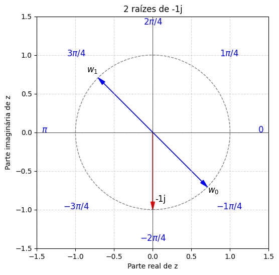

- Verifique que $w_k^n=-i$
- Verifique se $\bar{w_k}=(w_k*)$ também é raiz de função $f(z)=z^2+1$
- Quando o complexo conjugado de um polinômio também é raiz do polinômio? - Veja o exemplo do livro sobre fatoração!

#### Agora considere uma sequência

- Uma sequência de números complexos é uma função $f$ de tal forma que:
- $$f:\mathbb{N}\rightarrow\mathbb{C}$$
- $$w=f(n)={z_n},\quad n=1,2,3,4,\cdots$$

# Convergência de sequências complexas e exemplo $z_n=c^n$

- Definição. Uma sequência $(z_n)$ converge para $a\in\mathbb{C}$ se $\lim_{n\to\infty} z_n = a$. Equivalentemente, para todo $\varepsilon>0$ existe $N\in\mathbb{N}$ tal que $$ n\ge N \quad\Rightarrow\quad |z_n-a|<\epsilon. $$

Exemplo Seja $z_n=c^n$ com $c\in\mathbb{C}$ e $n\in\mathbb{N}$. Analisamos três casos segundo o módulo de $c$.

- (a) $|c|<1$

Temos $|z_n|=|c|^n$ e, como $0\le |c|<1$, segue que $\lim_{n\to\infty}|c|^n=0$. Portanto $z_n\to 0$.

- (b) $|c|>1$ Temos $|z_n|=|c|^n\to+\infty$ quando $n\to\infty$.
- (c) $|c|=1$ Escrevemos $c=e^{i\theta}$ com $\theta\in\mathbb{R}$. Então $$ z_n=c^n=e^{in\theta}, $$ ou seja, todos os termos ficam no círculo unitário. Existem dois subcasos importantes:
  - (c1) $\dfrac{\theta}{2\pi}\in$ Racionais

Se $\dfrac{\theta}{2\pi}=\dfrac{p}{q}$ com $q\in\mathbb{N}$, então $c^q=1$ e a sequência é periódica de período $q$ (assume no máximo $q$ valores). Uma sequência periódica não pode convergir para um único valor — a menos que seja constante. Logo, neste caso a sequência $c^n$ não converge, exceto se $c=1$ (quando $z_n\equiv 1$).

- (c2) $\dfrac{\theta}{2\pi}\in$ irracionais neste caso $c^n$ também não converge.
- Conclusão
- Se $|c|<1$ então $z_n=c^n\to 0$.
- Se $|c|>1$ então $|z_n|\to\infty$ e $z_n$ diverge.
- Se $|c|=1$ então $z_n$ permanece no círculo unitário e só converge no caso trivial $c=1$;

Definições:

- Se existe um $M\in\mathbb{R}$ tal que $|z_n|\le M$, para todo $n\in\mathbb{N}$, a sequência ${z_n}$ é limitada.
- Se para todo $\epsilon>0$, existe um $N\in\mathbb{N}$ tal que $M,n\ge N$, implica em $|z_M-z_n|<\epsilon$, a sequência {z_n} é dita ser uma sequência de Cauchy.
- ${w_k}$ é subsequência de ${z_n}$ se existe $\{n\in\mathbb{N}:w_k=z_{k_n},k\in\mathbb{N}\}$, $n_1<n_2<n_3<\cdots<n_j$, tais que $w_k=z_k, k=1,2,3,\cdots$

Dizemos que $(w_k)$ é uma subsequência de $(z_n)$ se existe uma sequência de índices estritamente crescente $(n_k)_{k\in\mathbb{N}}$ com $n_k\in\mathbb{N}$ tal que $$ w_k = z_{n_k}\qquad\text{para todo }k\in\mathbb{N}. $$ Em outras palavras, selecionamos alguns dos $n$ de $(z_n)$ mantendo a ordem original (índices crescentes) para formar $(w_k)$.

Exemplo com a sequência $z_n=c^n$ (do exemplo anterior): Tome $z_n=c^n$ e escolha $n_k=2k$. Obtemos $$ w_k = z_{n_k} = c^{2k}=(c^2)^k. $$ Este é um exemplo útil: por exemplo, se $|c|<1$ então $w_k\to 0$;

- Uma sequência complexa é convergente se e somente se for uma sequência de Cauchy.
- Toda sequência limitada de números complexos possui uma subsequência convergente.
  - Lembre-se do plano complexo e do exemplo anterior, e a condição de convergência

# Limites de funções

- Considere agora um subconjunto $S\in\mathbb{C}$ e $f:S\rightarrow\mathbb{C}$, onde S contém os pontos $z$ e o número $z_0$. Sendo $f$ definida numa vizinhaça deletada de $z_0$ $(0<|z-z_0|<\delta_0)$. O limite de $f$ à medida que $z$ tende a $z_0$ é o número complexo $L$. Representado por: $$\lim_{z\to z_0}f(z)=L$$ se, para todo $\epsilon>0$, existe $\delta>0$ tal que $$ 0<|z-z_0|<\delta \quad\Rightarrow\quad |f(z)-L|<\epsilon. $$

### Observações:

1. O ponto $z_0$ não precisa pertencer ao domínio $S$; basta que $f$ esteja definida em uma vizinhança deletada de $z_0$.
2. A definição é análoga ao caso real, mas aqui $z$ percorre o **plano complexo** (com infinitas direções de aproximação).
3. Se o limite existir, ele é único.

Além das propriedaddes aditivas e multiplicativas (vistas em sala de aula) temos:

Seja $f:S\to\mathbb{C}$ e $z_0$ ponto de acumulação de $S$.  
Suponha que $\displaystyle \lim_{z\to z_0} f(z) = L$.

- 1. $\displaystyle \bigl|\lim_{z\to z_0} f(z)\bigr| = \lim_{z\to z_0} |f(z)|$

Escrevemos $L = a + ib$ com $a,b\in\mathbb{R}$ e $f(z) = u(z) + i v(z)$, onde $u(z), v(z)$ são as partes real e imaginária de $f(z)$.
Como o limite de uma soma e produto é a soma e produto dos limites (propriedades usuais), temos: $$ \lim_{z\to z_0} u(z) = \operatorname{Re}(L) = u_0, \quad \lim_{z\to z_0} v(z) = \operatorname{Im}(L) = v_0. $$

Portanto, para o módulo: $$ \lim_{z\to z_0} |f(z)| = \lim_{z\to z_0} \sqrt{u(z)^2 + v(z)^2} = \sqrt{ (\lim u(z))^2 + (\lim v(z))^2 } = \sqrt{u_0^2 + v_0^2} = |L|. $$

Logo: $$ \bigl|\lim_{z\to z_0} f(z)\bigr| = \lim_{z\to z_0} |f(z)|. $$

- 2. $\displaystyle \bigl(\lim_{z\to z_0} f(z)\bigr)^* = \lim_{z\to z_0} f(z)^*$

Se $f(z) = u(z) + i v(z)$ e $L = a + ib$, o conjugado é $$ f(z)^* = u(z) - i v(z), \quad L^* = a - ib. $$ Como o limite preserva soma, subtração e multiplicação por constantes: $$ \lim_{z\to z_0} f(z)^* = \lim_{z\to z_0} \bigl(u(z) - i v(z)\bigr) = (\lim_{(x,y)\to (x_0,y_0)} u(x,y)) - i (\lim_{(x,y)\to (x_0,y_0)} v(z)) = u_0 - iv_0 = L^*. $$

Logo: $$ \bigl(\lim_{z\to z_0} f(z)\bigr)^* = \lim_{z\to z_0} f(z)^*. $$

- Observação Aqui usamos apenas propriedades de limites de funções reais aplicadas às partes real e imaginária, e o fato que o limite existe mesmo se $f(z)$ não for definida em $z_0$, sem recorrer a desigualdades. Veja a definição de limite: [...] Sendo $f$ definida numa vizinhaça deletada de $z_0$ $(0<|z-z_0|<\delta_0)$ .

# Continuidade

- Dada a função f, é pode ser escrita como a soma de uma parte real e imaginária, e é contínua em $z_0$ se e somente se suas partes reais e imaginárias são contínuas.
- $$\lim_{z\to z_0}f(z)\quad \mathrm{existe}$$
- $f(z)$ é definida em $z_0$.
- $$\lim_{z\to z_0} f(z)=f(z_0)$$

[output not shown]